# Project 2 - Mice are nice

Michał Frej, Agnieszka Sitko, Marcin Wojno

Modele liniowe i mieszane

### 1. Introduction - study description and overview

##### Study : KO

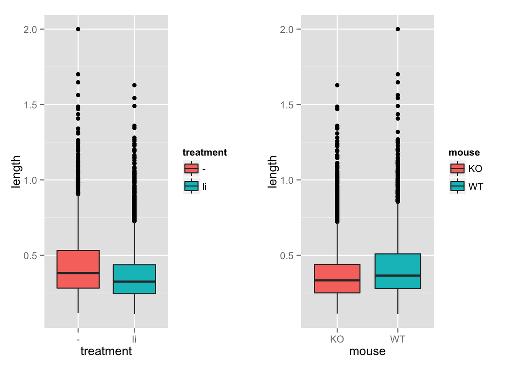

```r
selectedStudy <- "ko"
spines <- spines[Study==selectedStudy,]

lengthPerTreatment <- ggplot(data = spines, aes(x = treatment, y = length)) + geom_boxplot(aes(fill = treatment))
lengthPerMouseType <- ggplot(data = spines, aes(x = mouse, y = length))+geom_boxplot(aes(fill = mouse))

grid.arrange(lengthPerTreatment,lengthPerMouseType, ncol = 2)
```

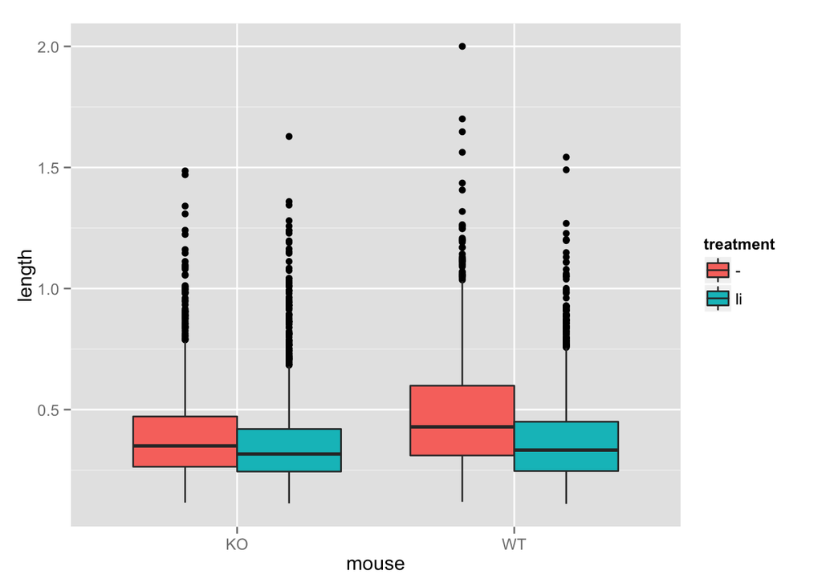

```r
(lengthPerMouseDifferentiatedByTreatment <- ggplot(data = spines, aes(x = mouse, y = length)) + geom_boxplot(aes(fill = treatment)))
```

### 2. Hypothesis

##### Interaction between mouse type and treatment

We may see significantly different means between different combinations of mouse and treatment

```
##    treatment        KO        WT
## 1:         - 0.3880219 0.4819959
## 2:        li 0.3632416 0.3745729
```

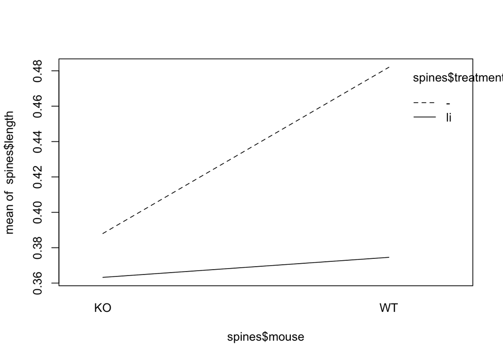

```r
interaction.plot(spines$mouse, spines$treatment, spines$length)
```

### 3. How we got there?

#### Maybe number of spines on the photo means something?

As we may observe, it doesn’t really matter

```r
spines[, noOfSpines := max(spine_number), by = 'Animal:Photo']
model <- lmer(length ~ treatment*mouse + (1|Animal) + (1|Photo_ID_abs), data = spines)
model_2 <- lmer(length ~ treatment*mouse + (1|Animal) + (1|Photo_ID_abs) + (1|noOfSpines), data = spines)
anova(model, model_2)
```

```
## Data: spines
## Models:
## model: length ~ treatment * mouse + (1 | Animal) + (1 | Photo_ID_abs)
## model_2: length ~ treatment * mouse + (1 | Animal) + (1 | Photo_ID_abs) +
## model_2:     (1 | noOfSpines)
##         Df     AIC     BIC logLik deviance Chisq Chi Df Pr(>Chisq)
## model    7 -2829.3 -2781.8 1421.7  -2843.3
## model_2  8 -2827.3 -2773.1 1421.7  -2843.3 2e-04      1     0.9892
```

#### Fixed effect shall be mouse and treatment

It is pretty straightforward from a logical point of view. Finding mouse type and treatment of a particular mouse is obvious (so it’s cheap) and there is comparatively small number of possible levels

#### Random effects shall be Animal and Photo

Effect of a single animal is random - every study and every year animals are just different individuals. After a quick look at the data we may see that number of photos per animal is irregular. Interestingly, for our study (i.e. KO) there is no such case that particular photo number occurs for two (or more) different animals.

#### So the model will be similar to length ~ treatment + mouse + (1|Animal/Photo)

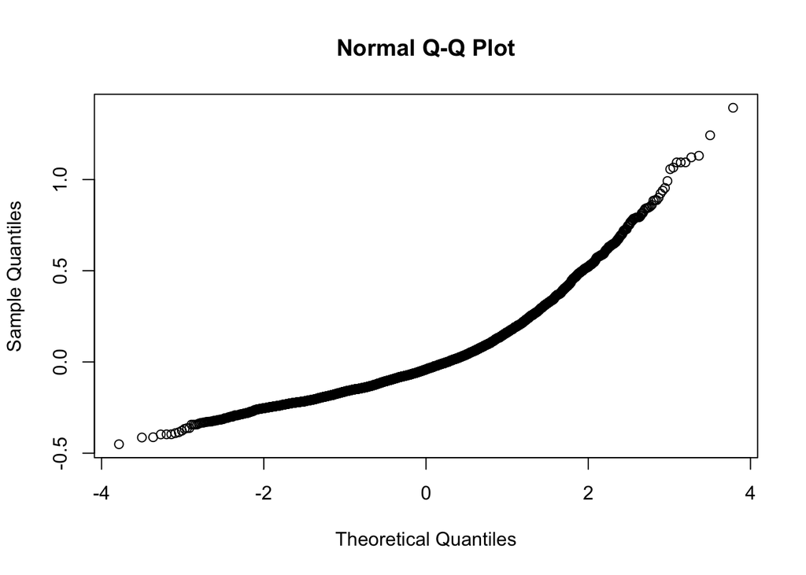

```r
modelZagniezdzony <- lmer(length ~ mouse * treatment+ (1|Animal/Photo_ID_abs), data = spines)
qqnorm(residuals(modelZagniezdzony),pch=1)
```

Unfortunately the assumptions of mixed models are not met, because residuals don’t have normal distribution. Looking at tail of this qqplot we guessed, that taking the logarithm of our dependant variable might be helpful.

We checked qqplots of many different models in logtrans and BoxCox class. After that we decided, that our model will be

```r
superModel <- lmer(log(length-0.03) ~ treatment*mouse + (1|Animal/Photo_ID_abs),
data = spines)
summary(superModel)
```

```
## Linear mixed model fit by REML ['lmerMod']
## Formula:
## log(length - 0.03) ~ treatment * mouse + (1 | Animal/Photo_ID_abs)
##    Data: spines
##
## REML criterion at convergence: 9280.2
##
## Scaled residuals:
##     Min      1Q  Median      3Q     Max
## -2.9411 -0.6623  0.0039  0.6463  3.3577
##
## Random effects:
##  Groups              Name        Variance Std.Dev.
##  Photo_ID_abs:Animal (Intercept) 0.004616 0.06794
##  Animal              (Intercept) 0.004772 0.06908
##  Residual                        0.239649 0.48954
## Number of obs: 6512, groups:  Photo_ID_abs:Animal, 65; Animal, 14
##
## Fixed effects:
##                     Estimate Std. Error t value
## (Intercept)         -1.15099    0.04567 -25.203
## treatmentli         -0.06956    0.06101  -1.140
## mouseWT              0.24433    0.06501   3.758
## treatmentli:mouseWT -0.21070    0.08602  -2.449
##
## Correlation of Fixed Effects:
##             (Intr) trtmnt mousWT
## treatmentli -0.749
## mouseWT     -0.702  0.526
## trtmntl:mWT  0.531 -0.709 -0.756
```

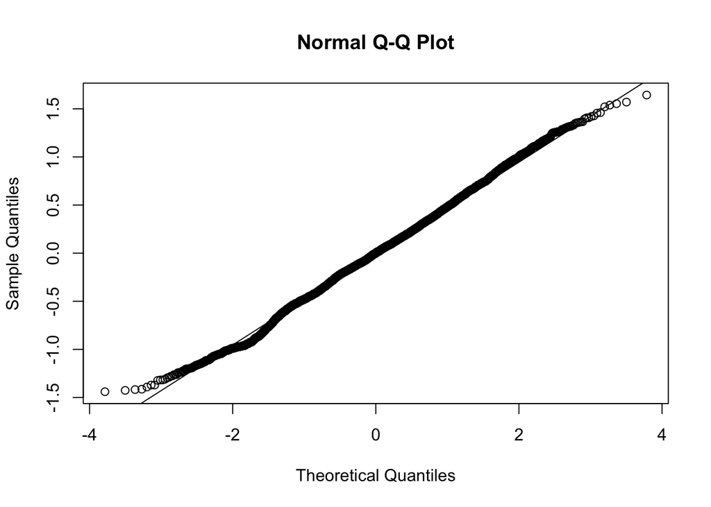

```r
par(mfrow = c(1,1))
qqnorm(residuals(superModel))
qqline(residuals(superModel))
```

Now we can assume, that the residuals follow the normal distribution. Another assumption is that u is normally distributed too. Let’s see whether it’s false or not.

```
## $`Photo_ID_abs:Animal`
```

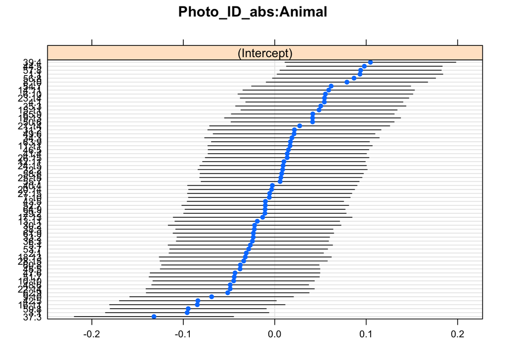

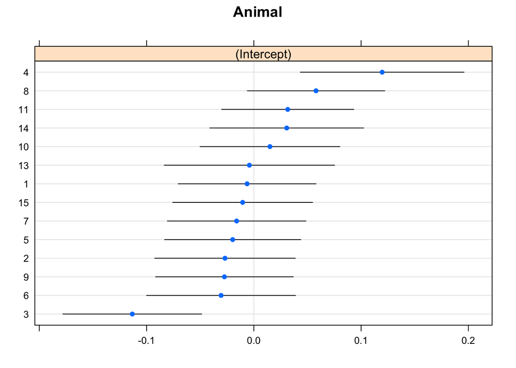

```r
library(lattice)
u=ranef(superModel,postVar=T)
dotplot(u)
```

```
## $`Photo_ID_abs:Animal`
```

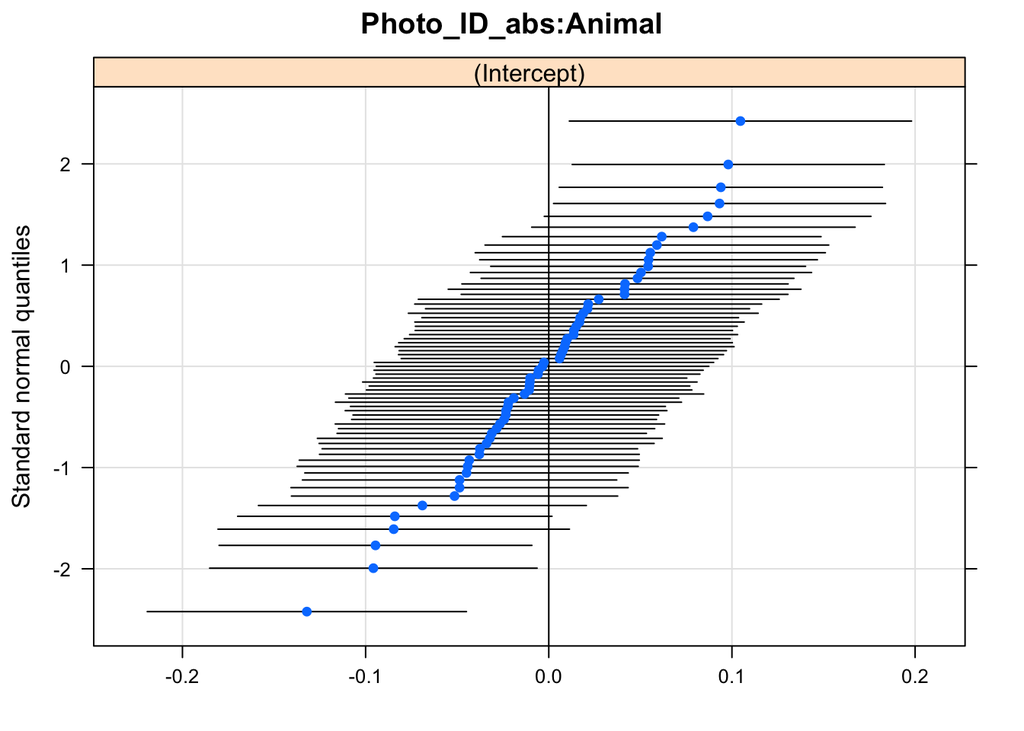

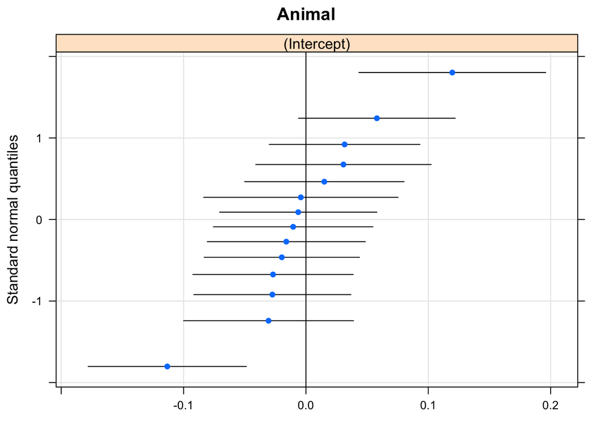

```r
qqmath(u)
```

Although middpoints of confidence intervals do not look exactly like normal cdf, we still can fit the theoretical normal cdf into our confidence intervals, therefore we don’t reject the hypothesis, that u has normal distribution.

#### Are all components of our model significant?

Firstly let’s check whether fixed effects are important by looking at p-values.

```r
tStat <- summary(superModel)$coeff[,3]
pValues <- sapply(1:length(tStat),function(i) {2*pnorm(abs(tStat[i]),lower.tail = F)})
pValues
```

```
##         (Intercept)         treatmentli             mouseWT
##       3.700881e-140        2.542569e-01        1.711818e-04
## treatmentli:mouseWT
##        1.430948e-02
```

This p-values give the same information as previously showed boxplots, that is intercept, mouse and interaction effects are significant, while treatment effect is not.

```r
N <- 1000
logs <- replicate(N, logLik(lmer(log(length-0.03) ~
treatment + mouse + sample(treatment:mouse) + (1|Animal/Photo_ID_abs), data = spines)))
mean(logs > logLik(superModel))
```

```
## [1] 0
```

We can check whether nested model is better then the simpler one by using ANOVA test.

```r
superModel2 <- lmer(log(length-0.03) ~ treatment*mouse + (1|Animal),
data = spines)

anova(superModel2, superModel)
```

```
## Data: spines
## Models:
## superModel2: log(length - 0.03) ~ treatment * mouse + (1 | Animal)
## superModel: log(length - 0.03) ~ treatment * mouse + (1 | Animal/Photo_ID_abs)
##             Df    AIC    BIC  logLik deviance  Chisq Chi Df Pr(>Chisq)
## superModel2  6 9315.5 9356.2 -4651.8   9303.5
## superModel   7 9275.5 9323.0 -4630.8   9261.5 41.995      1  9.152e-11 ***
## ---
## Signif. codes:  0 '***' 0.001 '**' 0.01 '*' 0.05 '.' 0.1 ' ' 1
```

Low Pr(>Chisq) indicates that we can’t neglect component (1|Animal:Photo_ID_abs), therefore our ituition, that random component should be of the form Animal/Photo_ID_abs was correct.

We showed, that our model is reasonable. Now we can check, by permutational test, if our hypothesis was correct. By permuting column with interaction effect we see, that indeed there is significant interaction between mouse type and treatment.

```r
N <- 1000
spines$interaction <- (spines$mouse=="WT")*(spines$treatment=="li")
logs <- replicate(N, logLik(lmer(log(length-0.03) ~ treatment + mouse + sample(interaction) + (1|Animal/Photo_ID_abs), data = spines)))
mean(logs > logLik(superModel))
```

```
## [1] 0.002
```

### 4. Conclusions

In study ‘ko’ both plots and computations show that there is an interaction between the mouse type and the treatment. Although the simplest model explaining length of spine doesn’t satisfy all assumptions of mixed models, by suitable transformation of data we can build a valid model, which shows the relation between length,treatment,mouse,animal and photo_ID_abs.

### 5. Literature

#### [1] Modele liniowe z efektami stałymi, losowymi i mieszanymi. P. Biecek

#### [2] www.google.com